# Proposal

Nhóm 5: Trần Văn Thắng, Trần Minh Đức, Lê Minh Hoàng

2022-11-06

```r
library(tidyverse)
library(dplyr)
library(ggplot2)
library(ggridges)
```

## 1. Giới thiệu

- Mục tiêu của nghiên cứu là phân tích tập dữ liệu nhà hàng thu được từ trang web “Zomato” và thực hiện các thử nghiệm giả thuyết thống kê khác nhau để kết luận được những thông tin có ý nghĩa từ dataset. Zomato là 1 nền tảng đặt đồ ăn lớn nhất của Ấn Độ, đây là một nền tảng mà khách hàng có thể gọi món từ những thành phố lớn của quốc gia này cũng như 1 vài thành phố lớn của các quốc gia lân cận.

  - Nghiên cứu kỹ lưỡng về dữ liệu sẽ giúp khám phá những hiểu biết sâu sắc có giá trị to lớn đối với khách hàng. Thông qua dữ liệu đã thu thập được và dựa trên các mô hình sẽ được tính toán nhằm đưa ra kết luận tốt nhất.
- Tập dữ liệu để phân tích được lấy từ trang web: [Dữ liệu nhà hàng Zomato | Kaggle](https://www.kaggle.com/datasets/shrutimehta/zomato-restaurants-data) Mỗi nhà hàng trong tập dữ liệu được xác định duy nhất bởi Id nhà hàng của nó. Mỗi Nhà hàng đều chứa các biến số sau:

  | Các biến số trong dataset: |
  | --- |
  | **1. Restaurant ID**: ID nhà hàng |
  | **2**. **Restaurant Name**: Tên nhà hàng |
  | **3. Country Code**: Mã quốc gia, nơi có nhà hàng |
  | **4. City**: Thành phố, nơi có nhà hàng |
  | **5. Address**: Địa chỉ nhà hàng |
  | **6. Locality**: Địa phương, vị trí trong thành phố |
  | **7. Locality Verbose**: Chi tiết về địa phương, mô tả chi tiết về địa phương |
  | **8. Longitude:** Tọa độ kinh độ vị trí của nhà hàng |
  | **9. Latitude:** Tọa độ vĩ độ vị trí của nhà hàng |
  | **10. Cuisines:** Món ăn,các loại món ăn do nhà hàng cung cấp |
  | **11. Average Cost for two:** Chi phí trung bình cho 2 người ăn |
  | **12. Currency**: Đơn vị tiền tệ |
  | **13. Has Table booking**: Có đặt bàn: Yes/No |
  | **14. Has Online delivery:** Có giao hàng trực tuyến: Yes/No |
  | **15. Is delivering now**: Đang giao hàng: Yes/No |
  | **16. Switch to order menu:** Chuyển sang menu gọi món: Yes/No |
  | **17. Price range:** phạm vi giá thức ăn (1-4) |
  | **18. Aggregate rating:** Xếp hạng tổng hợp(thang điểm 0-5 sao) |
  | **19. Rating color:** Màu đánh giá, tùy thuộc vào màu đánh giá trung bình (Orange,white, Yellow, Green, Dark Green) |
  | **20. Rating text:** Văn bản xếp hạng,trên cơ sở đánh giá xếp hạng (Average, Not rated, Good, Very Good,Excellent) |
  | **21. Votes:** Số phiếu bầu: Số lượng xếp hạng của mọi người |

#### *- Câu hỏi nghiên cứu:*

1. *Dữ liệu có cung cấp bằng chứng cho thấy những nhà hàng không cho đặt bàn trước có số lượt Votes nhiều hơn đáng kể so với những nhà hàng cho đặt trước hay không?*
2. *Dữ liệu có cung cấp bằng chứng cho thấy những nhà hàng không có giao hàng trực tuyến có số lượt Votes nhiều hơn đáng kể so với những nhà hàng có giao hàng trực tuyến hay không?*
3. *Dữ liệu có cung cấp bằng chứng cho thấy số tiền trung bình để 2 người ăn tại nhà hàng có quyết định số lượt Votes ở mỗi nhà hàng hay không?*
4. *Dữ liệu có cung cấp bằng chứng về “hiệu ứng cấp độ” đáng kể đối với số lượt vote hay không?*

## 2. Dữ liệu

- Đọc file dữ liệu

  ```r
  data <- read.csv("./data/zomato_restaurants.csv",header = T)
  ```

- Số lượng dòng và cột trong dataset

  ```r
  dim(data)
  ```

  ```
  ## [1] 369  21
  ```

  ```r
  names(data)
  ```

  ```
  ##  [1] "Restaurant.ID"        "Restaurant.Name"      "Country.Code"
  ##  [4] "City"                 "Address"              "Locality"
  ##  [7] "Locality.Verbose"     "Longitude"            "Latitude"
  ## [10] "Cuisines"             "Average.Cost.for.two" "Currency"
  ## [13] "Has.Table.booking"    "Has.Online.delivery"  "Is.delivering.now"
  ## [16] "Switch.to.order.menu" "Price.range"          "Aggregate.rating"
  ## [19] "Rating.color"         "Rating.text"          "Votes"
  ```

- Hiển thị thông tin , kiểu dữ liệu của các thuộc tính

  ```r
  str(data)
  ```

  ```
  ## 'data.frame':    369 obs. of  21 variables:
  ##  $ Restaurant.ID       : int  3400025 3400341 3400005 3400021 3400017 3400325 3400059 3400060 3400348 3400072 ...
  ##  $ Restaurant.Name     : chr  "Jahanpanah" "Rangrezz Restaurant" "Time2Eat - Mama Chicken" "Chokho Jeeman Marwari Jain Bhojanalya" ...
  ##  $ Country.Code        : int  1 1 1 1 1 1 1 1 1 1 ...
  ##  $ City                : chr  "Agra" "Agra" "Agra" "Agra" ...
  ##  $ Address             : chr  "E 23, Shopping Arcade, Sadar Bazaar, Agra Cantt, Agra" "E-20, Shopping Arcade, Sadar Bazaar, Agra Cantt, Agra" "Main Market, Sadar Bazaar, Agra Cantt, Agra" "1/48, Delhi Gate, Station Road, Raja Mandi, Civil Lines, Agra" ...
  ##  $ Locality            : chr  "Agra Cantt" "Agra Cantt" "Agra Cantt" "Civil Lines" ...
  ##  $ Locality.Verbose    : chr  "Agra Cantt, Agra" "Agra Cantt, Agra" "Agra Cantt, Agra" "Civil Lines, Agra" ...
  ##  $ Longitude           : num  78 0 78 78 78 ...
  ##  $ Latitude            : num  27.2 0 27.2 27.2 27.2 ...
  ##  $ Cuisines            : chr  "North Indian, Mughlai" "North Indian, Mughlai" "North Indian" "Rajasthani" ...
  ##  $ Average.Cost.for.two: int  850 700 500 400 1000 2000 2500 2500 800 3600 ...
  ##  $ Currency            : chr  "Indian Rupees(Rs.)" "Indian Rupees(Rs.)" "Indian Rupees(Rs.)" "Indian Rupees(Rs.)" ...
  ##  $ Has.Table.booking   : chr  "No" "No" "No" "No" ...
  ##  $ Has.Online.delivery : chr  "No" "No" "No" "No" ...
  ##  $ Is.delivering.now   : chr  "No" "No" "No" "No" ...
  ##  $ Switch.to.order.menu: chr  "No" "No" "No" "No" ...
  ##  $ Price.range         : int  3 2 2 2 3 4 4 4 3 4 ...
  ##  $ Aggregate.rating    : num  3.9 3.5 3.6 4 4.2 4 4.3 4 3.6 3.8 ...
  ##  $ Rating.color        : chr  "Yellow" "Yellow" "Yellow" "Green" ...
  ##  $ Rating.text         : chr  "Good" "Good" "Good" "Very Good" ...
  ##  $ Votes               : int  140 71 94 87 177 45 133 41 59 46 ...
  ```

- Hiển thị 5 dòng ngẫu nhiên.

  ```r
  sample_n(data,5)
  ```

  ```
  ##   Restaurant.ID                                        Restaurant.Name
  ## 1          8128                                      Mirage Restro Bar
  ## 2      18472426                                 Standard Chicken Point
  ## 3       2500024 Madhuban Restaurant - Welcome Hotel Rama International
  ## 4          2198                                                Welcome
  ## 5       2200045                                        The Kulcha Land
  ##   Country.Code       City
  ## 1            1  Faridabad
  ## 2            1  Faridabad
  ## 3            1 Aurangabad
  ## 4            1  Faridabad
  ## 5            1   Amritsar
  ##                                                                    Address
  ## 1           2nd Floor, Crown Plaza Mall, Sector 15-A, Sector 15, Faridabad
  ## 2                                 3F/90, Sainik Colony Road, NIT Faridabad
  ```

  [output cut: 39 more lines]

- Tổng số dòng mang giá trị na:

  ```r
  sum(is.na(data))
  ```

  ```
  ## [1] 0
  ```

## 3. Kế hoạch phân tích dữ liệu

#### a, Các biến kết quả và giải thích

- **Biến kết quả**: Votes
- **Biến giải thích**: Has Table booking, Has Online delivery, Average cost for two, Price range

#### b, Phân tích dữ liệu

- Để thuận tiện hơn trong việc phân tích chúng ta sẽ thống kê các nhà hàng có và không có dịch vụ đặt bàn trước, các nhà hàng có và không có dịch vụ giao hàng trực tuyến

  ```r
  has_booking <- subset(data,Has.Table.booking=="Yes")
  head(has_booking)
  ```

  ```
  ##     Restaurant.ID                  Restaurant.Name Country.Code      City
  ## 103         50943                 Sultans of Spice            1 Bangalore
  ## 104         58268 The Fatty Bao - Asian Gastro Bar            1 Bangalore
  ## 106      18162866              Three Dots & A Dash            1 Bangalore
  ## 113         54162                  The Black Pearl            1 Bangalore
  ## 117      18353121                         Flechazo            1 Bangalore
  ## 120         58882                      Big Brewsky            1 Bangalore
  ##                                                                                    Address
  ## 103          BluPetal Hotel, 60 Jyoti Nivas College Road, Koramangala 5th Block, Bangalore
  ## 104                    610, 3rd Floor, 12th Main, Off 80 Feet Road, Indiranagar, Bangalore
  ## 106                        840/1,100 Feet Road, Metro Pillar 56-57, Indiranagar, Bangalore
  ## 113     105, 1st A Cross Road, Jyothi Nivas College Road, Koramangala 5th Block, Bangalore
  ## 117 9/1, 1st Floor, Above Surya Nissan, VRR Orchid, Doddanakkundi, Marathahalli, Bangalore
  ## 120              Behind MK Retail, Before WIPRO Corporate Office, Sarjapur Road, Bangalore
  ##                        Locality                       Locality.Verbose
  ```

  [output cut: 41 more lines]

  ```r
  hasnt_booking <- subset(data,Has.Table.booking=="No")
  head(hasnt_booking)
  ```

  ```
  ##   Restaurant.ID                       Restaurant.Name Country.Code City
  ## 1       3400025                            Jahanpanah            1 Agra
  ## 2       3400341                   Rangrezz Restaurant            1 Agra
  ## 3       3400005               Time2Eat - Mama Chicken            1 Agra
  ## 4       3400021 Chokho Jeeman Marwari Jain Bhojanalya            1 Agra
  ## 5       3400017                        Pinch Of Spice            1 Agra
  ## 6       3400325                             MoMo Cafe            1 Agra
  ##                                                                          Address
  ## 1                          E 23, Shopping Arcade, Sadar Bazaar, Agra Cantt, Agra
  ## 2                          E-20, Shopping Arcade, Sadar Bazaar, Agra Cantt, Agra
  ## 3                                    Main Market, Sadar Bazaar, Agra Cantt, Agra
  ## 4                  1/48, Delhi Gate, Station Road, Raja Mandi, Civil Lines, Agra
  ## 5 23/453, Opposite Sanjay Cinema, Wazipura Road, Sanjay Place, Civil Lines, Agra
  ## 6             Courtyard by Marriott Agra, Phase 2, Fatehabad Road, Tajganj, Agra
  ##                              Locality                          Locality.Verbose
  ```

  [output cut: 34 more lines]

  ```r
  has_delivery <- subset(data,Has.Online.delivery=="Yes")
  head(has_delivery)
  ```

  ```
  ##    Restaurant.ID                        Restaurant.Name Country.Code      City
  ## 23      18396250                          Huber & Holly            1 Ahmedabad
  ## 25        113433                     Fozzie's Pizzaiolo            1 Ahmedabad
  ## 26      18438909                        La Pino'z Pizza            1 Ahmedabad
  ## 27      18143128                                  Mocha            1 Ahmedabad
  ## 28      18438944 Blue -  Rooftop Cafe Restaurant Bistro            1 Ahmedabad
  ## 33        110237                       Kabir Restaurant            1 Ahmedabad
  ##                                                                                      Address
  ## 23  7 B, Circle  B, Opposite Rajpath Club, Sarkhej, Gandhinagar Highway, Bodakdev, Ahmedabad
  ## 25    Ground Floor, Maruti Crystal, Opposite Rajpath Club, Service Road, Bodakdev, Ahmedabad
  ## 26                                        Shop 10,  Circle B, Nyay Marg, Bodakdev, Ahmedabad
  ## 27 6-9, Ground Floor, Devashish Business Park, Opposite Krishna Complex, Bodakdev, Ahmedabad
  ## 28         10th Floor, Balaji Heights Buliding, Behind Tanishq Showroom, C G Road, Ahmedabad
  ## 33                  JB Tower, Opposite Doordarshan Kendra, Drive In Road, Gurukul, Ahmedabad
  ##    Locality    Locality.Verbose Longitude Latitude
  ```

  [output cut: 34 more lines]

  ```r
  hasnt_delivery <- subset(data,Has.Online.delivery=="No")
  head(hasnt_delivery)
  ```

  ```
  ##   Restaurant.ID                       Restaurant.Name Country.Code City
  ## 1       3400025                            Jahanpanah            1 Agra
  ## 2       3400341                   Rangrezz Restaurant            1 Agra
  ## 3       3400005               Time2Eat - Mama Chicken            1 Agra
  ## 4       3400021 Chokho Jeeman Marwari Jain Bhojanalya            1 Agra
  ## 5       3400017                        Pinch Of Spice            1 Agra
  ## 6       3400325                             MoMo Cafe            1 Agra
  ##                                                                          Address
  ## 1                          E 23, Shopping Arcade, Sadar Bazaar, Agra Cantt, Agra
  ## 2                          E-20, Shopping Arcade, Sadar Bazaar, Agra Cantt, Agra
  ## 3                                    Main Market, Sadar Bazaar, Agra Cantt, Agra
  ## 4                  1/48, Delhi Gate, Station Road, Raja Mandi, Civil Lines, Agra
  ## 5 23/453, Opposite Sanjay Cinema, Wazipura Road, Sanjay Place, Civil Lines, Agra
  ## 6             Courtyard by Marriott Agra, Phase 2, Fatehabad Road, Tajganj, Agra
  ##                              Locality                          Locality.Verbose
  ```

  [output cut: 34 more lines]

- Dựa vào dataset ta sẽ thay thế các giá trị yes/no ở 2 cột Has Table booking và Has Online delivery bằng các giá trị 1/0 tương ứng để dễ dàng quan sát và phân tích

  ```r
  data$Has.Table.booking <- ifelse(data$Has.Table.booking=="Yes",1,0)
  data$Has.Online.delivery <- ifelse(data$Has.Online.delivery=="Yes",1,0)
  head(data)
  ```

  ```
  ##   Restaurant.ID                       Restaurant.Name Country.Code City
  ## 1       3400025                            Jahanpanah            1 Agra
  ## 2       3400341                   Rangrezz Restaurant            1 Agra
  ## 3       3400005               Time2Eat - Mama Chicken            1 Agra
  ## 4       3400021 Chokho Jeeman Marwari Jain Bhojanalya            1 Agra
  ## 5       3400017                        Pinch Of Spice            1 Agra
  ## 6       3400325                             MoMo Cafe            1 Agra
  ##                                                                          Address
  ## 1                          E 23, Shopping Arcade, Sadar Bazaar, Agra Cantt, Agra
  ## 2                          E-20, Shopping Arcade, Sadar Bazaar, Agra Cantt, Agra
  ## 3                                    Main Market, Sadar Bazaar, Agra Cantt, Agra
  ## 4                  1/48, Delhi Gate, Station Road, Raja Mandi, Civil Lines, Agra
  ## 5 23/453, Opposite Sanjay Cinema, Wazipura Road, Sanjay Place, Civil Lines, Agra
  ## 6             Courtyard by Marriott Agra, Phase 2, Fatehabad Road, Tajganj, Agra
  ##                              Locality                          Locality.Verbose
  ```

  [output cut: 34 more lines]

- Số tiền trung bình chi phí cho hai người bằng các đơn vị tiền tệ khác nhau thấp nhất và cao nhất trong mẫu chọn

  ```r
  min(data$Average.Cost.for.two)
  ```

  ```
  ## [1] 0
  ```

  ```r
  max(data$Average.Cost.for.two)
  ```

  ```
  ## [1] 150000
  ```

- 15 nhà hàng có lượt votes cao nhất

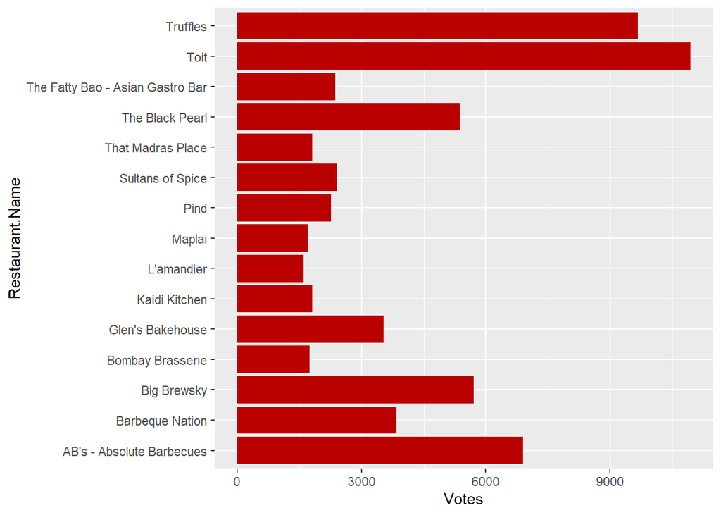

  ```r
  data %>%
    select(Restaurant.Name,Has.Table.booking,Has.Online.delivery,Average.Cost.for.two,Rating.color,Rating.text,Votes) %>%
    arrange(Votes) %>%
    tail(15)%>%
    ggplot(aes(x=Restaurant.Name,y=Votes))+
    geom_histogram(stat="identity",fill="#bb0000")+
    coord_flip()
  ```

- Số lượng nhà hàng có và không có dịch vụ đặt bàn trước

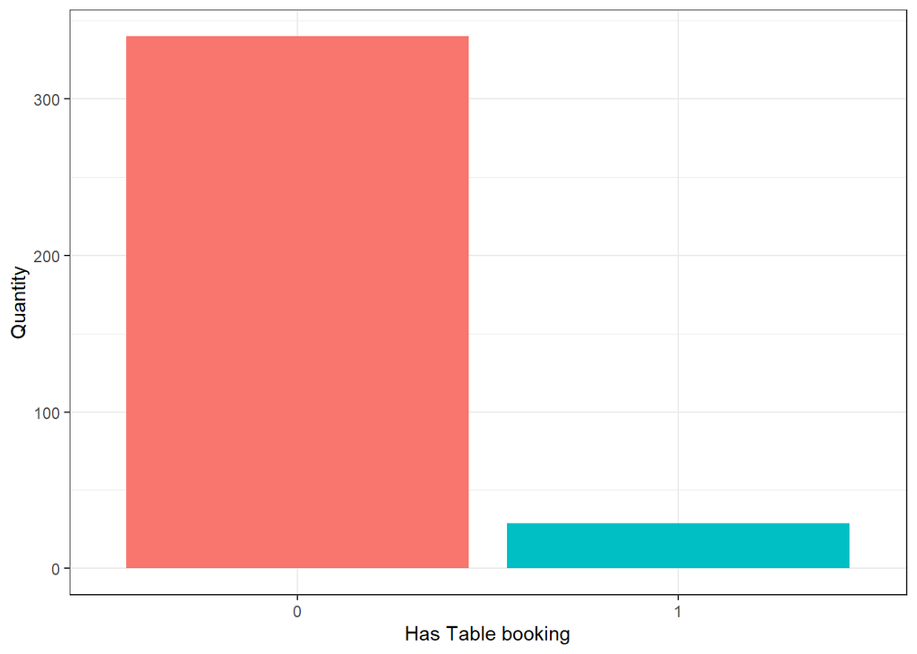

  ```r
  as.data.frame(table(data$Has.Table.booking)) %>%
    ggplot(aes(x=Var1,y=Freq,fill=Var1))+
      geom_bar(stat="identity",show.legend = FALSE) +
      xlab("Has Table booking")+
      ylab("Quantity")+
    theme_bw()
  ```

- Số lượng nhà hàng có và không có dịch vụ giao hàng online

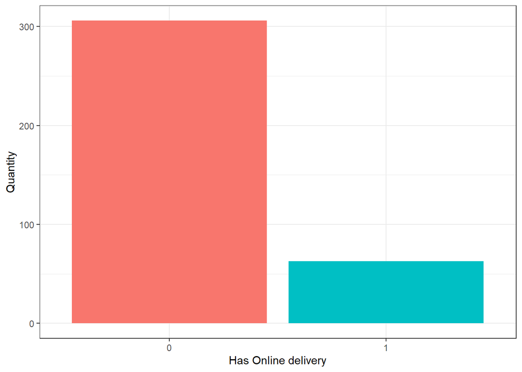

  ```r
  as.data.frame(table(data$Has.Online.delivery)) %>%
    ggplot(aes(x=Var1,y=Freq,fill=Var1))+
      geom_bar(stat="identity",show.legend = FALSE) +
      xlab("Has Online delivery")+
      ylab("Quantity")+
    theme_bw()
  ```

- Những nhà hàng có dịch vụ đặt bàn trước chủ yếu ở các thành phố

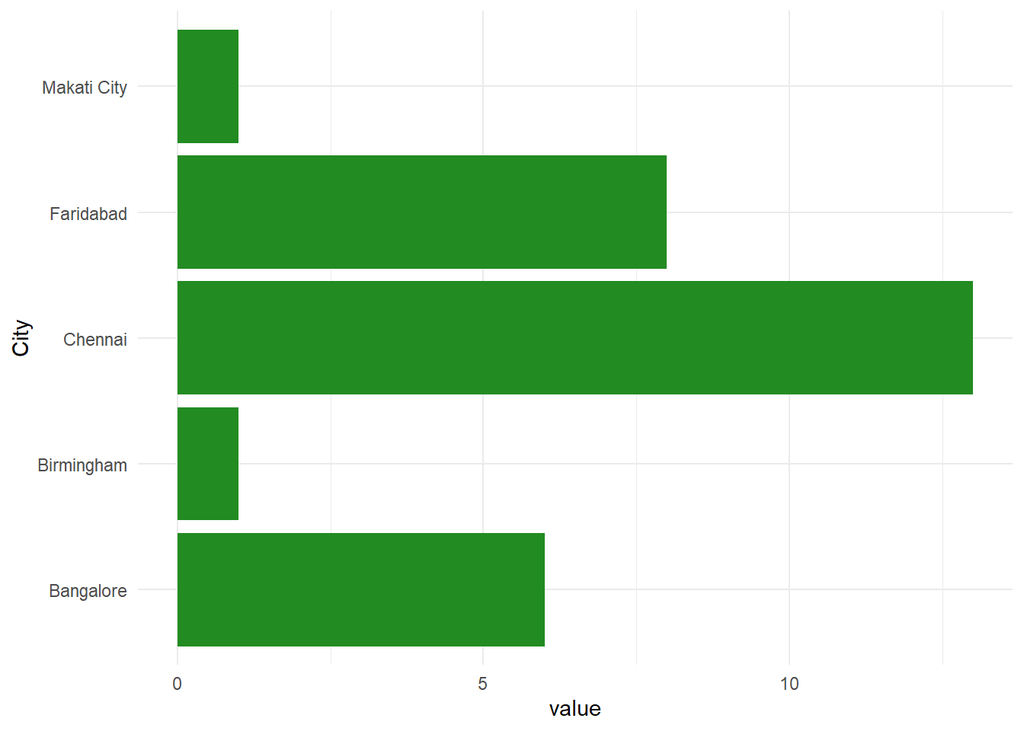

  ```r
  gg <- data %>%
          filter(Has.Table.booking==1) %>%
          select(City)
  as.data.frame(table(gg)) %>%
    ggplot(aes(x=City,y=Freq))+
    geom_bar(stat="identity",fill='forest green',show.legend = FALSE)+
    coord_flip()+
    ylab("value")+
    theme_minimal()
  ```

- Chi phí trung bình cho 2 người đối với phạm vi giá thức ăn phổ biến

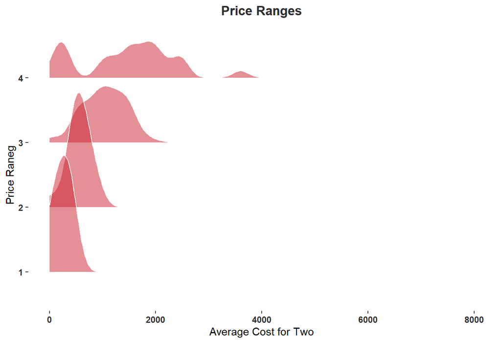

```r
data %>%
ggplot(aes(y = as.factor(Price.range))) +
  geom_density_ridges(aes(x = Average.Cost.for.two),
                      alpha = .5, color = "white", from = 0, to = 8000,fill='#cb202d') +
  labs(x = "Average Cost for Two",
       y = "Price Raneg",
       title = "Price Ranges",
       subtitle = "",
       caption = "")+
  theme(plot.title = element_text(hjust=0.5,face='bold',color='#2d2d2d'),panel.background = element_blank(),
        strip.text = element_text(face='bold',color='#2d2d2d'),axis.text.x = element_text(face='bold',color='#2d2d2d'),
        axis.text = element_text(face='bold',color='#2d2d2d'))
```

#### c, Các phương pháp giúp trả lời các câu hỏi đã đưa ra

- Sử dụng biểu đồ side-by-side boxplot để phù hợp hơn với các biến và đưa ra kết luận cho các câu hỏi đã đưa ra
- Sử dụng phương pháp phân tích dữ liệu thăm dò để giúp ta tóm tắt các đặc điểm quan trọng của dữ liệu
- Ví dụ: Ta có dữ liệu như sau: gồm biểu đồ và các thông tin cần thiết như min,max,mean… để trả lời câu hỏi 1

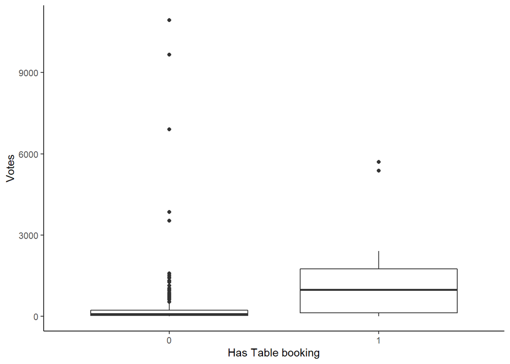

  ```r
  # x là explanatory variable
  # y là response variable

  # plot
     ggplot(data,aes(x=as.character(Has.Table.booking),y=Votes))+
  geom_boxplot()+
  theme_classic()+
       xlab("Has Table booking")+
      ylab("Votes")
  ```

  ```r
  # summary statistics
  tapply(data$Votes, factor(data$Has.Table.booking), summary)
  ```

  ```
  ## $`0`
  ##    Min. 1st Qu.  Median    Mean 3rd Qu.    Max.
  ##     0.0    35.0    94.0   292.7   225.8 10934.0
  ##
  ## $`1`
  ##    Min. 1st Qu.  Median    Mean 3rd Qu.    Max.
  ##       0     133     983    1262    1753    5705
  ```

- Ta đã biết được các đặc trưng quan trọng của dữ liệu sử dụng phân tích dữ liệu thăm dò. Bây giờ chúng ta chuyển sang đánh giá độ mạnh của bằng chứng do dữ liệu cung cấp bằng cách sử dụng các kiểm định thống kê.
- - Kiểm định thống kê phù hợp với câu hỏi: two sample t-test for two means ($\mu_1, \mu_2$)
  - Các giả thuyết: Null hypothesis: $H_0:\mu_1 - \mu_2 = 0$ và Alternative hypothesis: $H_A:\mu_1 - \mu_2 < 0$
- *Tiến hành trả lời các câu hỏi:*

**1**, Dữ liệu có cung cấp bằng chứng cho thấy những nhà hàng không cho đặt bàn trước có số lượt Votes nhiều hơn đáng kể so với những nhà hàng cho đặt trước hay không?

- Để thực hiện kiểm định thống kê, ta tính test statistic:

  ```r
  mu1 = mean(hasnt_booking$Votes)
  mu2 = mean(has_booking$Votes)

  n1 = sum(table(has_booking$Has.Table.booking))
  n2 = sum(table(hasnt_booking$Has.Table.booking))

  s1 = var(has_booking$Votes)
  s2 = var(hasnt_booking$Votes)

  se = sqrt(s1/n1 + s2/n2)

  t = (mu1 - mu2)/se
  t
  ```

  ```
  ## [1] -3.579928
  ```

  ```r
  v = (s1/n1 + s2/n2)^2/((s1/n1)^2/(n1-1) + (s2/n2)^2/(n2-1))
  v
  ```

  ```
  ## [1] 30.08496
  ```

  ```r
  p_value = pt(q = t, df = v)
  p_value
  ```

  ```
  ## [1] 0.0005951193
  ```

- Kiểm tra lại `T-test` trong R

  ```r
  #Kiểm định H0: m1 - m2 = 0
  #Phủ định giả thuyết Ha: m1 - m2 < 0 <=> m1 < m2
  t.test(data$Votes~data$Has.Table.booking, alternative="less")
  ```

  ```
  ##
  ##  Welch Two Sample t-test
  ##
  ## data:  data$Votes by data$Has.Table.booking
  ## t = -3.5799, df = 30.085, p-value = 0.0005951
  ## alternative hypothesis: true difference in means between group 0 and group 1 is less than 0
  ## 95 percent confidence interval:
  ##       -Inf -509.5895
  ## sample estimates:
  ## mean in group 0 mean in group 1
  ##        292.6706       1261.5862
  ```

- Kết quả: Vì $p$-value nhỏ hơn mức ý nghĩa $\alpha = 0.05$ nên ta bác bỏ $H_0$.
- Kết luận:
  - Phân tích thăm dò cho thấy sự khác biệt về số votes giữa nhà hàng cho đặt bàn trước và không cho đặt bàn trước.Cụ thể hơn,bỏ qua mặt số lượng nhà hàng thì những nhà hàng cho đặt bàn trước thường có số vote cao hơn những nhà hàng không cho đặt bàn trước.
  - Kiểm định thống kê cho ra giá trị $p$ rất nhỏ (về cơ bản là 0), cho thấy bằng chứng được cung cấp bởi dữ liệu đủ mạnh để bác bỏ $H_0$.
  - Đây là một nghiên cứu quan sát, không có kết luận nhân quả nào có thể được đưa ra. Trường hợp duy nhất mà từ có mối quan hệ có thể suy ra nhân quả (association implies causation) là khi nghiên cứu là một thí nghiệm ngẫu nhiên. Có thể giải thích cho sự khác biệt giữa hai nhóm kiểu nhà hàng là những nhà hàng cho đặt bàn trước tận tâm hơn, dịch vụ chăm sóc khách hàng cũng tốt hơn nên sẽ nhân được lượng vote nhiều hơn
  - Kết quả này có thể được cung cấp cho các nhà hàng để phát triển hơn, nhưng nên lưu ý với họ rằng không chỉ là việc đặt bàn trước mà còn là chất lượng phục vụ và món ăn của nhà hàng mới là những yếu tô quyết định.

**2**. Dữ liệu có cung cấp bằng chứng cho thấy những nhà hàng không có giao hàng trực tuyến có số lượt Votes nhiều hơn đáng kể so với những nhà hàng có giao hàng trực tuyến hay không?

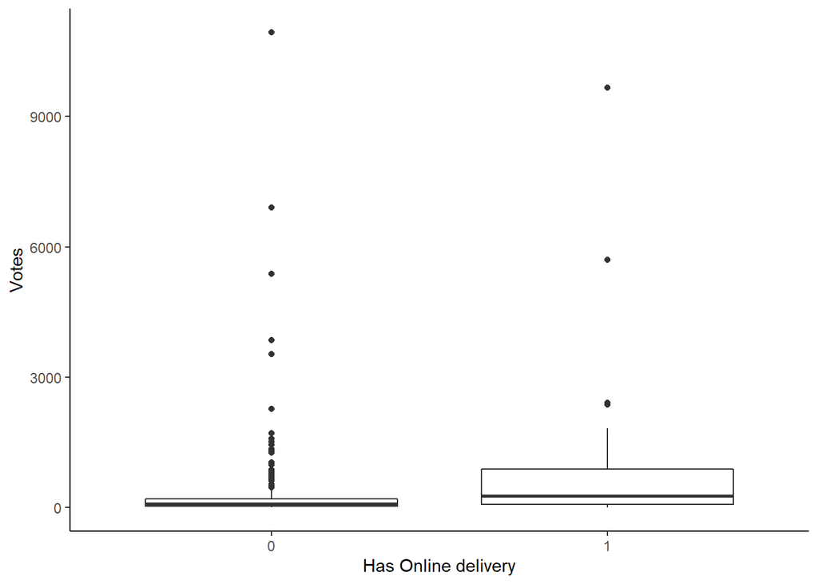

```r
# x là explanatory variable
# y là response variable

# plot
ggplot(data,aes(x=as.character(Has.Online.delivery),y=Votes))+
  geom_boxplot()+
  theme_classic()+
   xlab("Has Online delivery")+
    ylab("Votes")
```

```r
# summary statistics
tapply(data$Votes, factor(data$Has.Online.delivery), summary)
```

```
## $`0`
##     Min.  1st Qu.   Median     Mean  3rd Qu.     Max.
##     0.00    32.25    88.50   284.82   198.50 10934.00
##
## $`1`
##    Min. 1st Qu.  Median    Mean 3rd Qu.    Max.
##     7.0    74.0   265.0   776.8   892.5  9667.0
```

- Để thực hiện kiểm định thống kê, ta tính test statistic:

  ```r
  mu1 = mean(hasnt_delivery$Votes)
  mu2 = mean(has_delivery$Votes)

  n1 = sum(table(hasnt_delivery$Has.Online.delivery))
  n2 = sum(table(has_delivery$Has.Online.delivery))

  s1 = var(hasnt_delivery$Votes)
  s2 = var(has_delivery$Votes)

  se = sqrt(s1/n1 + s2/n2)

  t = (mu1 - mu2)/se
  t
  ```

  ```
  ## [1] -2.601474
  ```

  ```r
  v = (s1/n1 + s2/n2)^2/((s1/n1)^2/(n1-1) + (s2/n2)^2/(n2-1))
  v
  ```

  ```
  ## [1] 71.81704
  ```

  ```r
  p_value = pt(q = t, df = v)
  p_value
  ```

  ```
  ## [1] 0.005632668
  ```

- Kiểm tra lại `T-test` trong R

  ```r
  #Kiểm định H0: m1 - m2 = 0
  #Phủ định giả thuyết Ha: m1 - m2 < 0 <=> m1 < m2
  t.test(data$Votes~data$Has.Online.delivery, alternative="less")
  ```

  ```
  ##
  ##  Welch Two Sample t-test
  ##
  ## data:  data$Votes by data$Has.Online.delivery
  ## t = -2.6015, df = 71.817, p-value = 0.005633
  ## alternative hypothesis: true difference in means between group 0 and group 1 is less than 0
  ## 95 percent confidence interval:
  ##       -Inf -176.8434
  ## sample estimates:
  ## mean in group 0 mean in group 1
  ##        284.8235        776.7937
  ```

- Kết quả: Vì $p$-value nhỏ hơn mức ý nghĩa $\alpha = 0.05$ nên ta bác bỏ Null hypothesis : $H_0$.
- Kết luận:
  - Phân tích thăm dò cho thấy sự khác biệt rõ rệt về số votes giữa nhà hàng có giao hàng online và không có giao hàng online .Cụ thể hơn, những nhà hàng có giao hàng online thường có số vote cao hơn những nhà hàng không có giao hàng online
  - Kiểm định thống kê cho ra giá trị $p$ rất nhỏ (về cơ bản là 0), cho thấy bằng chứng được cung cấp bởi dữ liệu đủ mạnh để bác bỏ $H_0$ và kết luận rằng tổng số votes giữa những nhà hàng không có giao hàng online là kém hơn đáng kể so với những nhà hàng có giao hàng online
  - Đây là một nghiên cứu quan sát, không có kết luận nhân quả nào có thể được đưa ra. Trường hợp duy nhất mà từ có mối quan hệ có thể suy ra nhân quả (association implies causation) là khi nghiên cứu là một thí nghiệm ngẫu nhiên. Có thể giải thích cho sự khác biệt giữa hai nhóm kiểu nhà hàng là những nhà hàng có giao hàng online sẽ thuận tiện hơn cho khách ở xa dịch vụ chăm sóc khách hàng cũng tốt hơn nên sẽ nhân được lượng vote nhiều hơn.
  - Kết quả này có thể được cung cấp cho các nhà hàng để phát triển hơn, nhưng nên lưu ý với họ rằng không chỉ là có giao hàng online mà còn là chất lượng phục vụ và món ăn của nhà hàng mới là những yếu tô quyết định

- Bước tiếp theo, chúng ta giải thích kết quả nhận được từ các phân tích trong bối cảnh của câu hỏi hiện tại.
- Kết quả nhận được cho thấy điều gì về sự khác biệt về tổng số votes giữa những nhà hàng cho đặt trước và không cho đặt trước?

#### d, Kế hoạch thực hiện và phân công việc

|  | Trần Văn Thắng | Trần Minh Đức | Lê Minh Hoàng |
| --- | --- | --- | --- |
| chuẩn bị đề tài, đọc lướt dữ liệu | x | x | x |
| đăt và trả lời các câu hỏi: | x | x | x |
| câu hỏi 1 | x | x |  |
| câu hỏi 2 |  | x | x |
| câu hỏi 3 | x |  | x |
| câu hỏi 4 | x | x | x |
| đưa ra các kết luận | x | x | x |
| Tìm hiểu về các phương pháp để phân tích dữ liệu như phân tích dữ liệu thăm dò, kiểm định thống kê | x | x | x |
|  | 100% | 100% | 100% |